# Red Wine Exploration

Since ph measures acid concentration using log scale, therefore the correlation between ph and the log of acid concentration is stronger. A linear model can help us tell the variance in ph level of the acidity variables

[output not shown]

```
##
## Call:
## lm(formula = pH ~ I(log10(citric.acid)) + I(log10(volatile.acidity)) +
##     I(log10(fixed.acidity)), data = subset(wine, citric.acid >
##     0))
##
## Residuals:
##      Min       1Q   Median       3Q      Max
## -0.47184 -0.06318 -0.00003  0.06447  0.32265
##
## Coefficients:
##                             Estimate Std. Error t value Pr(>|t|)
## (Intercept)                 4.230862   0.040578 104.266  < 2e-16 ***
## I(log10(citric.acid))      -0.052187   0.008797  -5.933 3.72e-09 ***
## I(log10(volatile.acidity)) -0.049788   0.021248  -2.343   0.0193 *
## I(log10(fixed.acidity))    -1.071983   0.038987 -27.496  < 2e-16 ***
## ---
## Signif. codes:  0 '***' 0.001 '**' 0.01 '*' 0.05 '.' 0.1 ' ' 1
##
## Residual standard error: 0.1068 on 1463 degrees of freedom
## Multiple R-squared:  0.4876, Adjusted R-squared:  0.4866
## F-statistic: 464.1 on 3 and 1463 DF,  p-value: < 2.2e-16
```

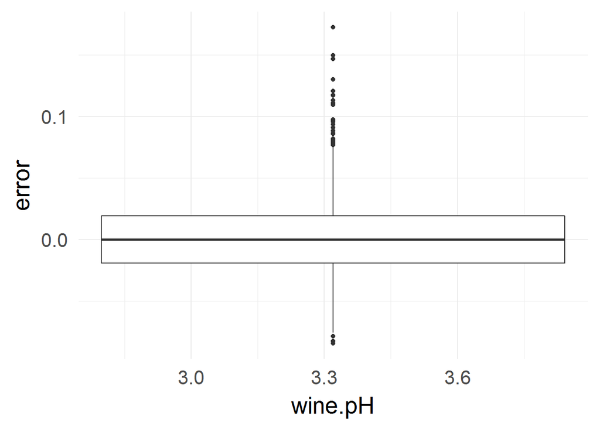

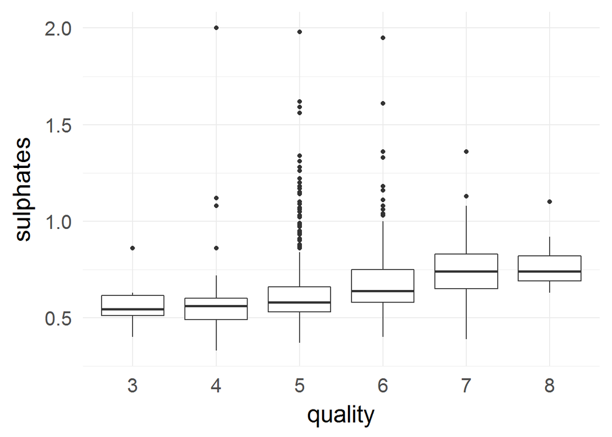

Summaries for sulphates grouped by quality

| quality | mean | median |
| --- | --- | --- |
| 3 | 0.5700000 | 0.545 |
| 4 | 0.5964151 | 0.560 |
| 5 | 0.6209692 | 0.580 |
| 6 | 0.6753292 | 0.640 |
| 7 | 0.7412563 | 0.740 |
| 8 | 0.7677778 | 0.740 |

Good quality wines seems to have higher sulphates concentration.

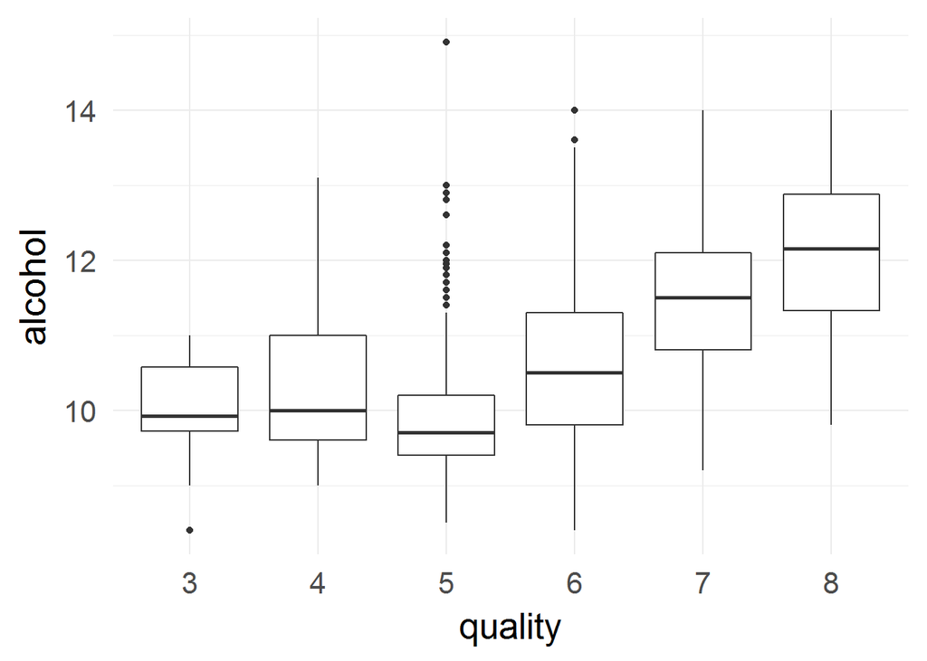

Summaries for alcohol grouped by quality

| quality | mean | median |
| --- | --- | --- |
| 3 | 9.955000 | 9.925 |
| 4 | 10.265094 | 10.000 |
| 5 | 9.899706 | 9.700 |
| 6 | 10.629519 | 10.500 |
| 7 | 11.465913 | 11.500 |
| 8 | 12.094444 | 12.150 |

Here we see an increase in alcohol graduation gives an increase in the concentration of better graded wines. Given the high number of outliers it seems we cannot rely on alcohol alone to produce better wines.

Let’s try using a simple linear model to investigate.

```
##
## Call:
## lm(formula = as.numeric(quality) ~ alcohol, data = wine)
##
## Residuals:
##     Min      1Q  Median      3Q     Max
## -2.8442 -0.4112 -0.1690  0.5166  2.5888
##
## Coefficients:
##             Estimate Std. Error t value Pr(>|t|)
## (Intercept) -0.12503    0.17471  -0.716    0.474
## alcohol      0.36084    0.01668  21.639   <2e-16 ***
## ---
## Signif. codes:  0 '***' 0.001 '**' 0.01 '*' 0.05 '.' 0.1 ' ' 1
##
## Residual standard error: 0.7104 on 1597 degrees of freedom
## Multiple R-squared:  0.2267, Adjusted R-squared:  0.2263
## F-statistic: 468.3 on 1 and 1597 DF,  p-value: < 2.2e-16
```

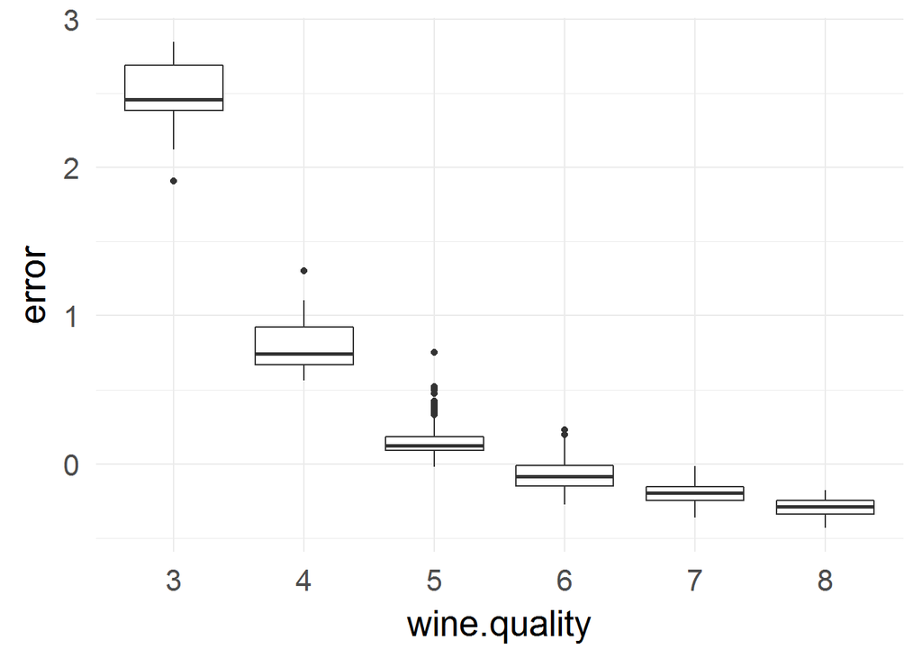

It seems seems alcohol alone only explains about 22% of the variance in quality. Other variables needs to be explored to generate a better model.

# Bivariate Analysis

### Talk about some of the relationships you observed in this part of the

investigation. How did the feature(s) of interest vary with other features in the dataset? Here are my observations:

Fixed.acidity seems to have little to no effect on quality

Volatile acidity has and inverse relation

Citirc acidity ith higer concentration produces better quality in wines

it was surprising to see that residula sugar has little or no effect on the quality od wine

Eventtough the corelation is not too strong, a lower concentration of chlorides seem to produce better wines.

Better wines tend to have lower densities.

pH:it seems better wines are more acid (but there were many outliers). Better wines also seem to have a higher concentration of sulphates.

the Linear model tells that if some other variables were added it might generate a bette rmodel, but we can substantiate that Alcohol graduation has a strong correlation with quality, but it cannot explain all the variance.

### Did you observe any interesting relationships between the other features (not the main feature(s) of interest)?

there is a strong relation between free and total sulfur.dioxide.

### What was the strongest relationship you found?

The relationship between the variables total.sulfur.dioxide and free.sulfur.dioxide.

# Multivariate Plots Section

### Alcohol and other variables

Using multivariate plots to answer some questions encountered and to look for other relationships in the data.

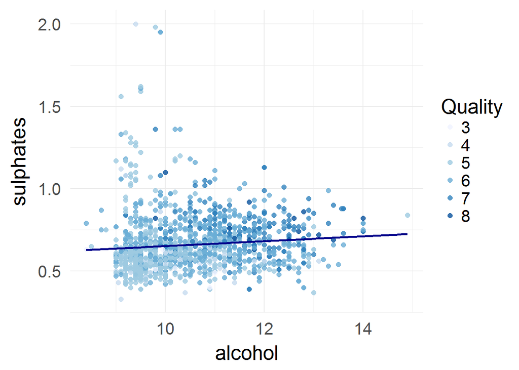

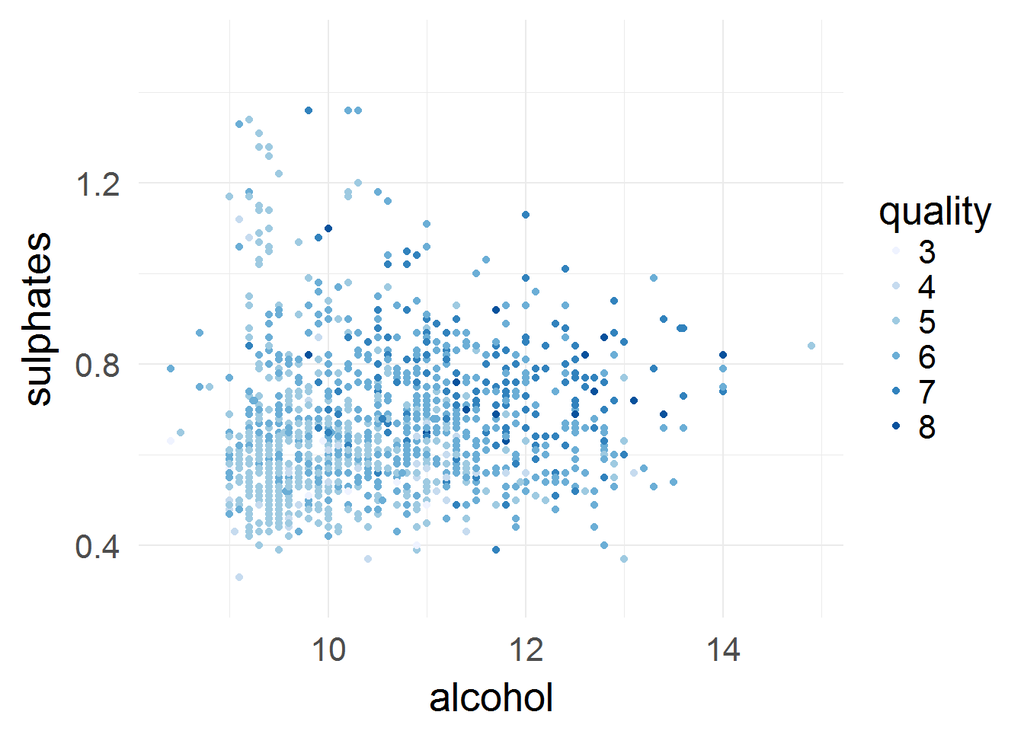

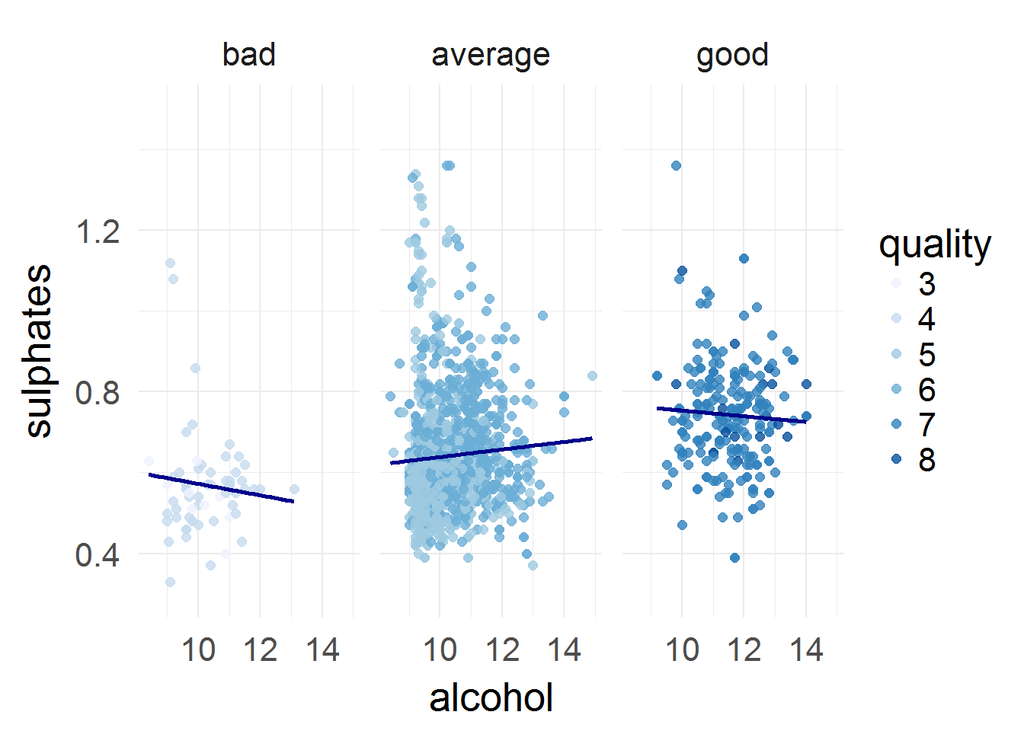

worth noting thatbfor wines with high alcohol content, having a higher concentration of sulphates will produce better wines.

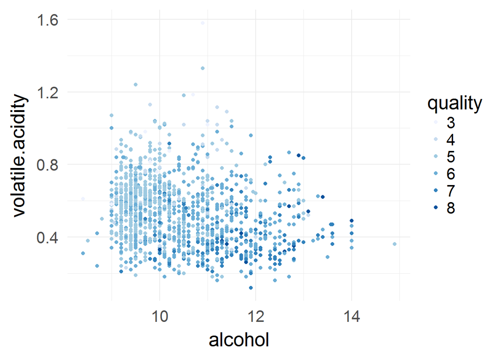

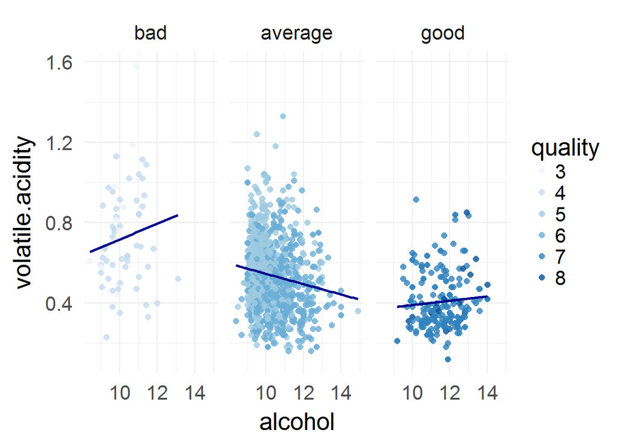

For volatile acidity,having less acetic acid on higher concentration of alcohol seems to produce better wines.

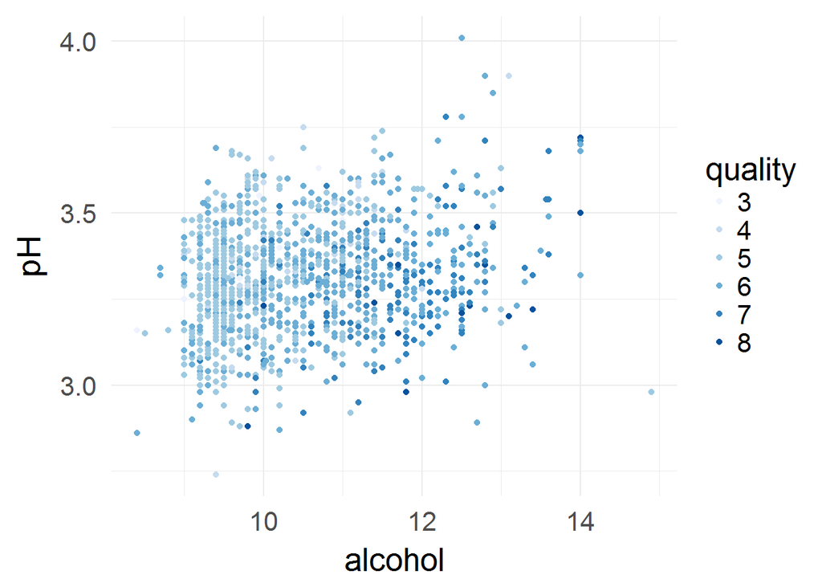

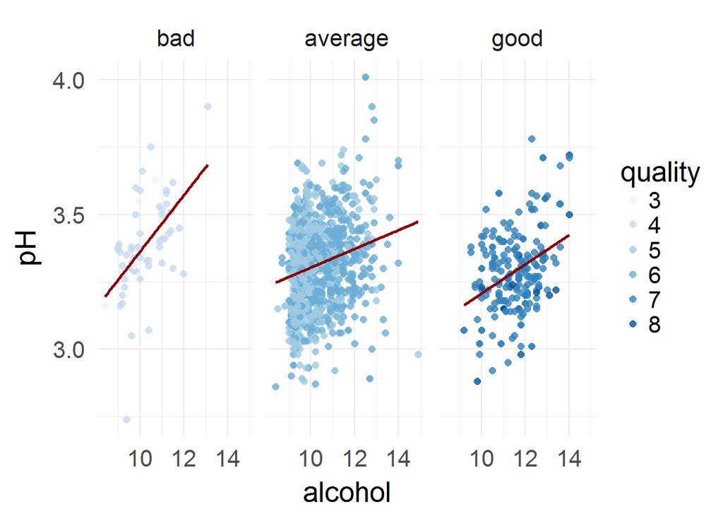

Low pH and high alcohol concentration seem to work well.

### Acid exploration

Using multivariate plots to further investigate the relationship between the acids and quality.

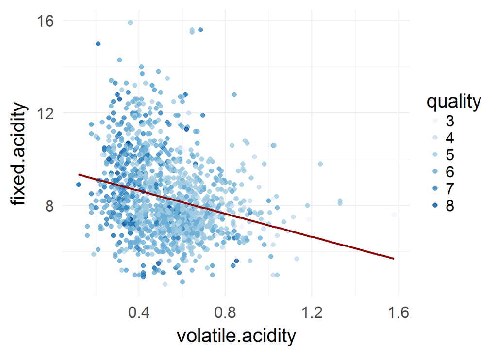

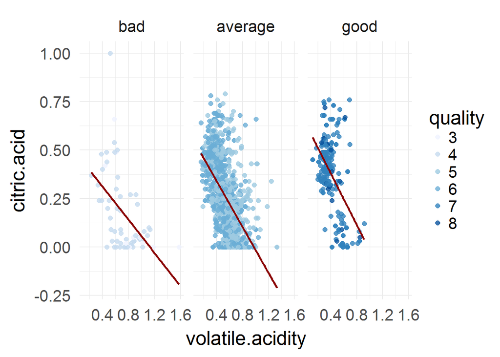

High citric acid and low acetic acid seems like a good combination.

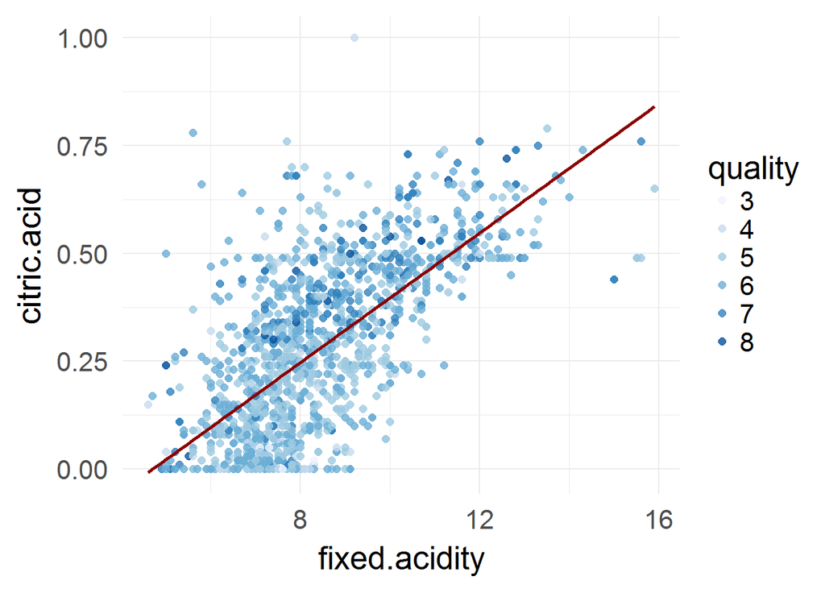

```
##
##  Pearson's product-moment correlation
##
## data:  wine$citric.acid and wine$fixed.acidity
## t = 36.234, df = 1597, p-value < 2.2e-16
## alternative hypothesis: true correlation is not equal to 0
## 95 percent confidence interval:
##  0.6438839 0.6977493
## sample estimates:
##       cor
## 0.6717034
```

Although there seems to be a correlation between tartaric acid and citric acid concentrations, nothing stands out in terms of quality.

```
##
## Calls:
## m1: lm(formula = as.numeric(quality) ~ alcohol, data = training_data)
## m2: lm(formula = as.numeric(quality) ~ alcohol + sulphates, data = training_data)
## m3: lm(formula = as.numeric(quality) ~ alcohol + sulphates + volatile.acidity,
##     data = training_data)
## m4: lm(formula = as.numeric(quality) ~ alcohol + sulphates + volatile.acidity +
##     citric.acid, data = training_data)
## m5: lm(formula = as.numeric(quality) ~ alcohol + sulphates + volatile.acidity +
##     citric.acid + fixed.acidity, data = training_data)
## m6: lm(formula = as.numeric(quality) ~ alcohol + sulphates + pH,
##     data = training_data)
##
## ======================================================================================
##                        m1         m2         m3         m4         m5         m6
## --------------------------------------------------------------------------------------
##   (Intercept)       -0.066     -0.604**    0.605*     0.670**    0.294      1.328*
##                     (0.220)    (0.224)    (0.248)    (0.257)    (0.289)    (0.516)
##   alcohol            0.357***   0.339***   0.306***   0.305***   0.315***   0.362***
##                     (0.021)    (0.020)    (0.020)    (0.020)    (0.020)    (0.021)
##   sulphates                     1.099***   0.745***   0.770***   0.780***   0.980***
##                                (0.138)    (0.137)    (0.139)    (0.138)    (0.139)
##   volatile.acidity                        -1.199***  -1.272***  -1.333***
##                                           (0.125)    (0.146)    (0.147)
##   citric.acid                                        -0.128     -0.436*
##                                                      (0.130)    (0.170)
##   fixed.acidity                                                  0.047**
##                                                                 (0.017)
##   pH                                                                       -0.631***
##                                                                            (0.152)
## --------------------------------------------------------------------------------------
##   R-squared              0.2       0.3        0.3        0.3        0.3        0.3
##   adj. R-squared         0.2       0.3        0.3        0.3        0.3        0.3
##   sigma                  0.7       0.7        0.7        0.7        0.6        0.7
##   F                    289.0     185.9      166.2      124.9      102.2      131.8
##   p                      0.0       0.0        0.0        0.0        0.0        0.0
##   Log-likelihood     -1022.5    -991.5     -947.7     -947.2     -943.2     -983.0
##   Deviance             473.7     444.0      405.2      404.8      401.5      436.2
##   AIC                 2051.1    1991.1     1905.4     1906.4     1900.5     1976.0
##   BIC                 2065.7    2010.5     1929.7     1935.6     1934.5     2000.3
##   N                    959       959        959        959        959        959
## ======================================================================================
```

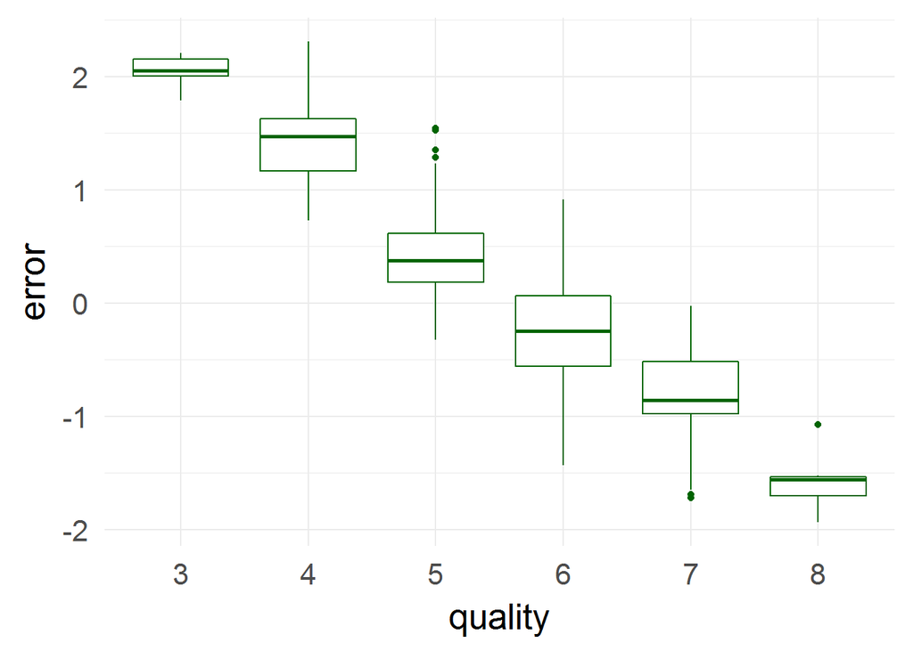

# Multivariate Analysis

### Talk about some of the relationships you observed in this part of the investigation. Were there features that strengthened each other in terms of looking at your feature(s) of interest?

if one wants a very good wine, one should have a high alcohol content and high sulphate concentrations combined

### Were there any interesting or surprising interactions between features?

yes alcohol and density. one does not affect the other.

### OPTIONAL: Did you create any models with your dataset? Discuss the strengths and limitations of your model.

- variables: alcohol, sulphates, and the acid variables. Both the residuals plot and the cross validation favors average wines. This is probably a reflection of the high number of average wines in the training dataset or it could mean that there is missing information that would help predict the edge cases.

Maybe the dataset has some errors

# Final Plots and Summary

### Plot One

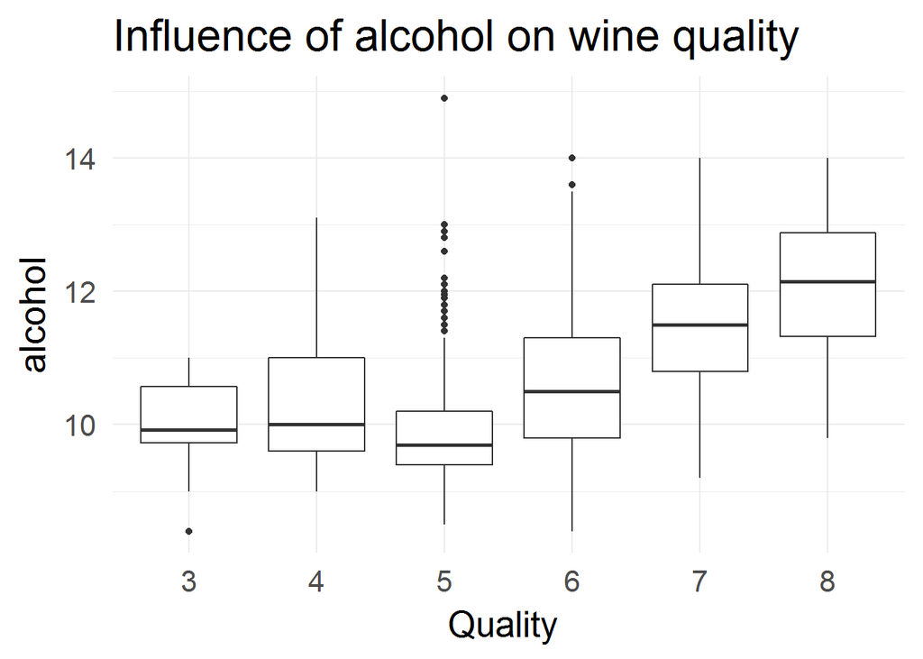

### Plot Two

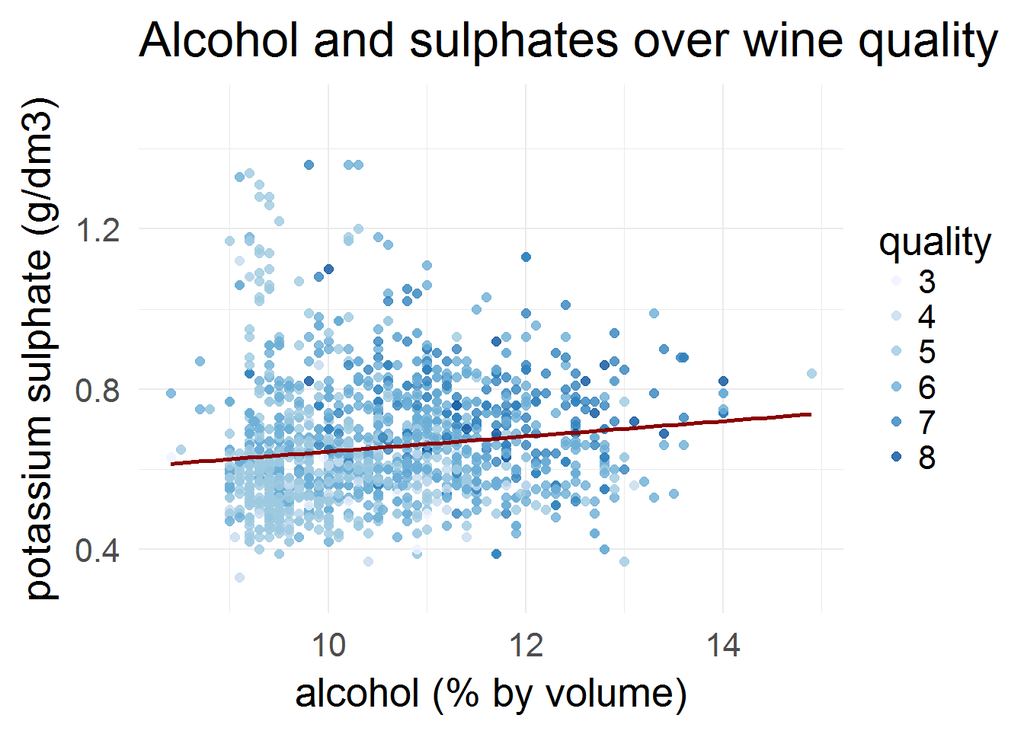

### Description Two

Using a scatterplot, this graph is aimed at identifying the unique “content profile” of quality wines by combining the two most important factors (sulphates and alcohol). The graph shows that as wine quality improves, with increase in alcohol and sulphate. To be able to ignore the outliers just eyeball the cloud of dots to locate a general trend, a scatter plot with regression line was used which helps me to make a discernable connection between the 3 things investigate dhere (alcohol, sulphates and quality) Combining the two High alcohol contents and high sulphate concentrations seem to produce better wines.

### Plot Three

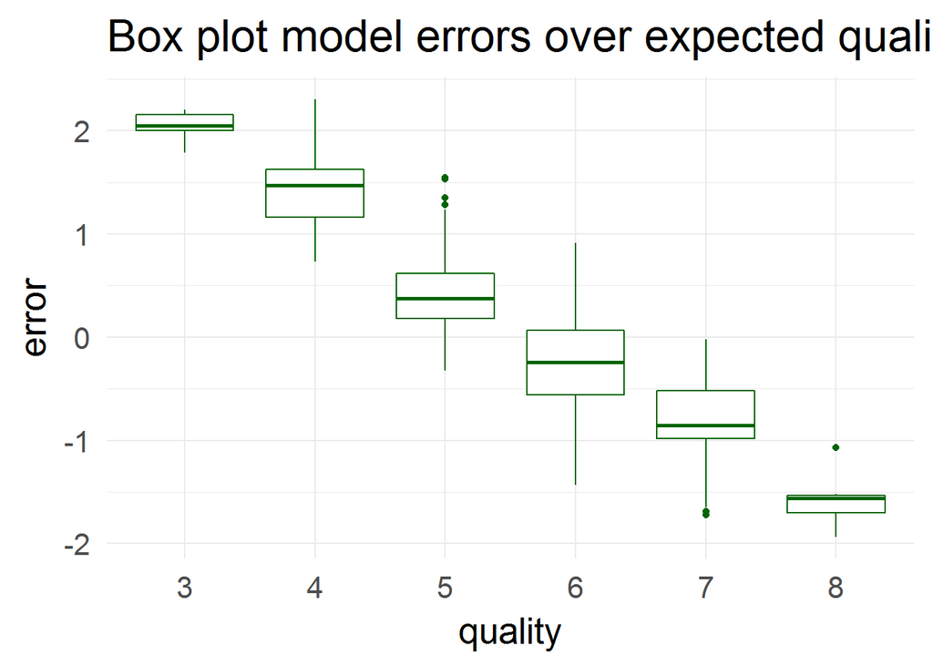

### Description Three

# Reflection

The wine data set contains information on the chemical properties of a selection of wines collected in 2009. It also includes sensorial data (wine ranking).

By looking at the individual distributions of the variables, to see how they relate to quality.

it was quick to notice the high concentration of wines in the middle ranges of the ranking, that is, average tasting wines.this raise eyebrows of a true correlation between the variables or maybe for lack of outlier. None of the correlations were above 0.7, however. The two variables that had relatively strong correlations were alcohol percentage and volatile acidity, but the individual correlations were not strong enough to make definitive conclusions with only bivariate analysis methods Citric acid stood out because as research shows citric acid is sometimes added to wines to boost overall acidity.

[researching the subject](https://en.wikipedia.org/wiki/Acids_in_wine#Citric_acid)

having said that the plots shows a strange distribution with some peaks but showing an almost rectangular distribution specially in the 0-0.5 range.

All of the other variables showed either an normal or long tailed looking distribution.

Next step was to see how the variables relate with each other to produce poor or better quality

This shows alcohol concentration, sulphates and the individual acid concentrations.

I also tried investigating the effect of each acid in the overall pH for the wine. I used scatterplots to explore the relationships graphically and also generated a linear model to check how much of pH the three variables accounted for.

Having a positive ph for correlation between acetic acid concentration suggests the presence of some lurking variable (Simpsons paradox) using“Simpsons” package I confirmed that suspicion.

Finding out that the concentration of the three acids only account for less than half of the variance in pH, tells that there more components affecting acidity that were not measured.

For future studies, including malic and lactic acid would be interesting to mesure as these improves the taste. This data set may include storage time and storage method since these factors can influence the quality of wine as well. Also, maybe the relationship between price and quality of wine to investigate whether expensive wines lead to better quality. [Wikipedia](https://en.wikipedia.org/wiki/Acids_in_wine) for example,

Maybe the dataset can have entry for the individuals judgemnt on the flavor, aroma (if can be clasiified), to make an interesting analysis.

### Reference

1.Udacity teaching material 2.research on Simpsons paradox 3.discussion forum on udacity 4.stackoverflow 5.google 6.wikipedia